Example 3.

```python
# compute statistics in a rolling window
df_window = df.sort_values('num_var1').rolling(15)
x_winmean = df_window.mean()['num_var1']
y_median = df_window.median()['num_var2']
y_q1 = df_window.quantile(.25)['num_var2']
y_q3 = df_window.quantile(.75)['num_var2']

# plot the summarized data
base_color = sb.color_palette()[0]
line_color = sb.color_palette('dark')[0]
plt.scatter(data = df, x = 'num_var1', y = 'num_var2')
plt.errorbar(x = x_winmean, y = y_median, c = line_color)
plt.errorbar(x = x_winmean, y = y_q1, c = line_color, linestyle = '--')
plt.errorbar(x = x_winmean, y = y_q3, c = line_color, linestyle = '--')

plt.xlabel('num_var1')
plt.ylabel('num_var2')
```

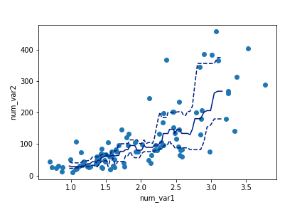

```python
bin_edges = np.arange(-3, df['num_var'].max()+1/3, 1/3)
g = sb.FacetGrid(data = df, hue = 'cat_var', size = 5)
g.map(plt.hist, "num_var", bins = bin_edges, histtype = 'step')
g.add_legend()
```

Note that I'm performing the multiple hist calls through the use of FacetGrid, setting the categorical variable on the "hue" parameter rather than the "col" parameter. You'll see more of this parameter of FacetGrid in the next lesson. I've also added an add_legend method call so that we can identify which level is associated with each curve.

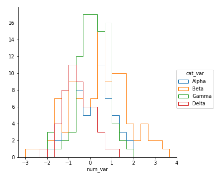

```python
l1 = np.array([0,1,2,4,4,5,7])
#l2 = [0,1,2,4,4,4,6]
(l1[1:] + l1[:-1] )/2
```

```
array([0.5, 1.5, 3. , 4. , 4.5, 6. ])
```

```python
def freq_poly(x, bins = 10, **kwargs):
    """ Custom frequency polygon / line plot code. """
    # set bin edges if none or int specified
    if type(bins) == int:
        bins = np.linspace(x.min(), x.max(), bins+1)
    bin_centers = (bin_edges[1:] + bin_edges[:-1]) / 2

    # compute counts
    data_bins = pd.cut(x, bins, right = False,
                       include_lowest = True)
    counts = x.groupby(data_bins).count()

    # create plot
    plt.errorbar(x = bin_centers, y = counts, **kwargs)

bin_edges = np.arange(-3, df['num_var'].max()+1/3, 1/3)
g = sb.FacetGrid(data = df, hue = 'cat_var', size = 5)
g.map(freq_poly, "num_var", bins = bin_edges)
g.add_legend()
```

Functions you provide to the map method of FacetGrid objects do not need to be built-ins. Below, I've written a function to perform the summarization operations seen above to plot an errorbar line for each level of the categorical variable, then fed that function (freq_poly) to map.

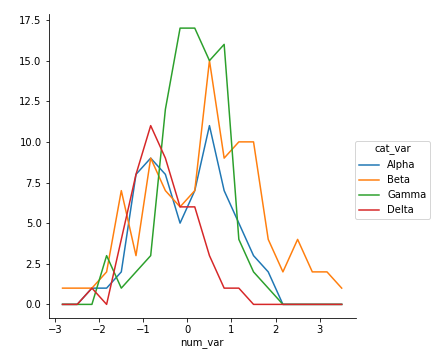

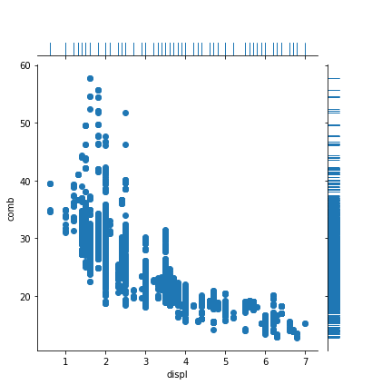

```python
g = sns.JointGrid(data = fuel_econ, x = 'displ', y = 'comb')
g.plot_joint(plt.scatter)
g.plot_marginals(sns.rugplot, height = 0.25)
```

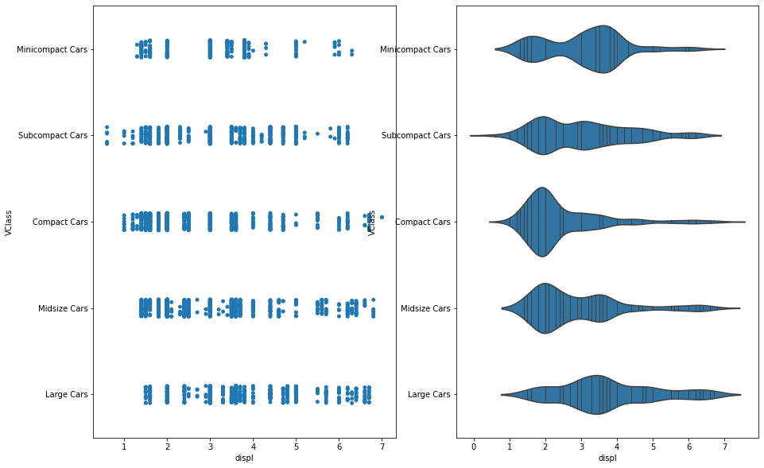

```python
plt.figure(figsize = [15, 10])
base_color = sns.color_palette()[0]

# left plot: strip plot
plt.subplot(1, 2, 1)
ax1 = sns.stripplot(data = fuel_econ, x = 'displ', y = 'VClass',
                   color = base_color)

# right plot: violin plot with inner strip plot as lines
plt.subplot(1, 2, 2)
sns.violinplot(data = fuel_econ, x = 'displ', y = 'VClass', color = base_color,
             inner = 'stick')
#plt.ylim(ax1.get_ylim());
```

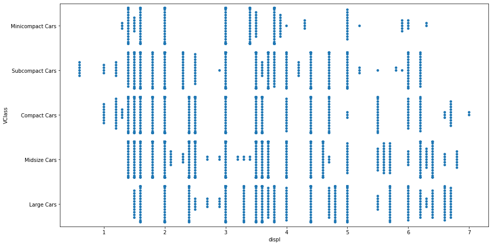

```python
plt.figure(figsize=[15,8])
sns.swarmplot(data = fuel_econ, x = 'displ', y = 'VClass', color = base_color)
```

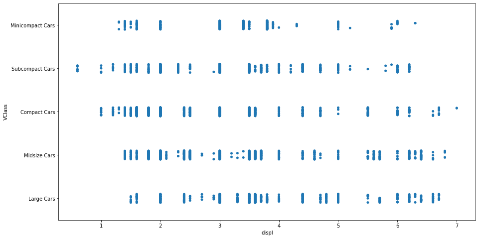

```python
plt.figure(figsize=[15,8])
sns.stripplot(data = fuel_econ, x = 'displ', y = 'VClass', color = base_color)
```

```
(0.0, 2.0)
```

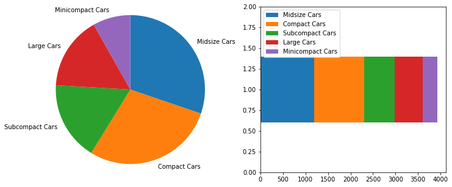

```python
# pre-processing: count and sort by the number of instances of each category
sorted_counts = fuel_econ['VClass'].value_counts()

# establish the Figure
plt.figure(figsize = [12, 5])

# left plot: pie chart
plt.subplot(1, 2, 1)
plt.pie(sorted_counts, labels = sorted_counts.index, startangle = 90,
        counterclock = False);
plt.axis('square');

# right plot: horizontally stacked bar
plt.subplot(1, 2, 2)
baseline = 0
for i in range(sorted_counts.shape[0]):
    plt.barh(y = 1, width = sorted_counts[i], left = baseline)
    baseline += sorted_counts[i]

plt.legend(sorted_counts.index)  # add a legend for labeling
plt.ylim([0,2]) # give some vertical spacing around the bar
```

[output not shown]

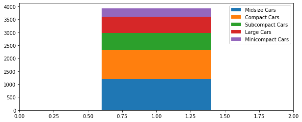

```python
#fig, ax = plt.subplots()

sorted_counts = fuel_econ['VClass'].value_counts()
plt.figure(figsize=(10,4))
base = 0

for i in range(len(sorted_counts)):
    plt.bar(x=1,height = sorted_counts[i],bottom=base)
    base +=sorted_counts[i]

plt.legend(sorted_counts.index)
plt.xlim([0,2]);
```

```python
cat1_order = ['East', 'South', 'West', 'North']
cat2_order = ['Type X', 'Type Y', 'Type Z', 'Type O']

plt.figure(figsize = [12, 5])

# left plot: clustered bar chart, absolute counts
plt.subplot(1, 2, 1)
sb.countplot(data = df, x = 'cat_var1', hue = 'cat_var2',
             order = cat1_order, hue_order = cat2_order)
plt.legend()

# right plot: stacked bar chart, absolute counts
plt.subplot(1, 2, 2)

baselines = np.zeros(len(cat1_order))
# for each second-variable category:
for i in range(len(cat2_order)):
    # isolate the counts of the first category,
    cat2 = cat2_order[i]
    inner_counts = df[df['cat_var2'] == cat2]['cat_var1'].value_counts()
    # then plot those counts on top of the accumulated baseline
    plt.bar(x = np.arange(len(cat1_order)), height = inner_counts[cat1_order],
            bottom = baselines)
    baselines += inner_counts[cat1_order]

plt.xticks(np.arange(len(cat1_order)), cat1_order)
plt.legend(cat2_order)
```

```
Midsize Cars        640
Compact Cars        490
Large Cars          256
Subcompact Cars     132
Minicompact Cars      3
Name: VClass, dtype: int64

 Minicompact Cars      3
Subcompact Cars     132
Compact Cars        490
Midsize Cars        640
Large Cars          256
Name: VClass, dtype: int64


Compact Cars        593
Subcompact Cars     534
Midsize Cars        509
Large Cars          348
Minicompact Cars    318
Name: VClass, dtype: int64

 Minicompact Cars    318
Subcompact Cars     534
Compact Cars        593
Midsize Cars        509
Large Cars          348
Name: VClass, dtype: int64
```

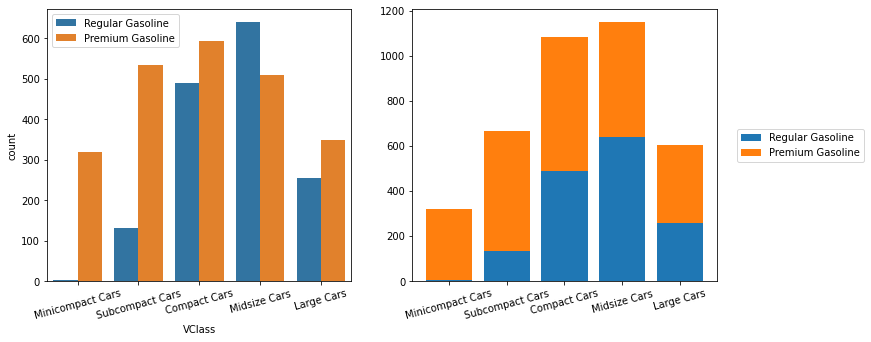

```python
cat1_order = ['Minicompact Cars' , 'Subcompact Cars' ,'Compact Cars' , 'Midsize Cars' ,'Large Cars']
cat2_order = ['Regular Gasoline', 'Premium Gasoline']

plt.figure(figsize = [12, 5])

# left plot: clustered bar chart, absolute counts
plt.subplot(1, 2, 1)
sns.countplot(data = fuel_econ, x = 'VClass', hue = 'fuelType',
             order = cat1_order, hue_order = cat2_order)
plt.xticks(rotation=15)
plt.legend()

# right plot: stacked bar chart, absolute counts
plt.subplot(1, 2, 2)
baselines = np.zeros(len(cat1_order))
# for each second-variable category:
for i in range(len(cat2_order)):
    # isolate the counts of the first category,
    cat2 = cat2_order[i]
    inner_counts = fuel_econ[fuel_econ['fuelType'] == cat2]['VClass'].value_counts()
    print(inner_counts,'\n \n' , inner_counts[cat1_order],'\n \n')
    # then plot those counts on top of the accumulated baseline
    plt.bar(x = np.arange(len(cat1_order)), height = inner_counts[cat1_order],
            bottom = baselines)
    baselines += inner_counts[cat1_order]

plt.xticks(np.arange(len(cat1_order)), cat1_order)
plt.xticks(rotation=15)
plt.legend(cat2_order,loc=5,bbox_to_anchor=(1.5,0.5))
```

```python
query.unstack(level=1).plot(kind='bar',rot=15)
```

```
VClass            fuelType
Midsize Cars      Regular Gasoline    640
Compact Cars      Premium Gasoline    593
Subcompact Cars   Premium Gasoline    534
Midsize Cars      Premium Gasoline    509
Compact Cars      Regular Gasoline    490
Large Cars        Premium Gasoline    348
Minicompact Cars  Premium Gasoline    318
Large Cars        Regular Gasoline    256
Subcompact Cars   Regular Gasoline    132
Minicompact Cars  Regular Gasoline      3
dtype: int64
```

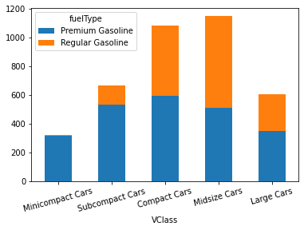

```python
query = fuel_econ.query('fuelType in ("Regular Gasoline","Premium Gasoline")')[['VClass','fuelType']].value_counts()

query.unstack(level=1).plot(kind='bar',rot=15,stacked=True)
query
```

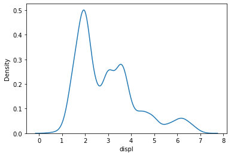

```python
sns.kdeplot(fuel_econ['displ'], shade=False)
```

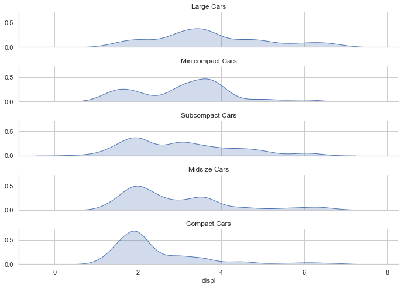

```python
group_means = fuel_econ.groupby(['VClass']).mean()
group_order = group_means.sort_values(['displ'], ascending = False).index

g = sns.FacetGrid(data = fuel_econ, row = 'VClass', size = 1.4, aspect = 7,
                 row_order = group_order)
sns.set_theme(style='whitegrid')
g.map(sns.kdeplot, 'displ', shade = True)
g.set_titles('{row_name}')

#g.set(ylim=(np.arange(0,2)))
```

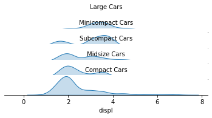

```python
# adjust the spacing of subplots with gridspec_kws
g = sns.FacetGrid(data = fuel_econ, row = 'VClass', size = 0.5, aspect = 12,
                 row_order = group_order, gridspec_kws = {'hspace' : -0.2})  # By setting "hspec" to a negative value, the subplot axes bounds will overlap vertically.
g.map(sns.kdeplot, 'displ', shade = True)

# remove the y-axes
g.set(yticks=[])
g.despine(left=True)

g.set_titles('{row_name}')
```

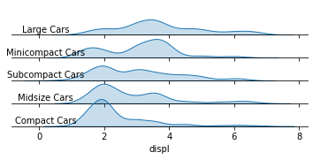

```python
# adjust the spacing of subplots with gridspec_kws
g = sns.FacetGrid(data = fuel_econ, row = 'VClass', size = 0.5, aspect = 12,
                 row_order = group_order, gridspec_kws = {'hspace' : -0.2})  # By setting "hspec" to a negative value, the subplot axes bounds will overlap vertically.
g.map(sns.kdeplot, 'displ', shade = True)

# remove the y-axes
g.set(yticks=[])
g.despine(left=True)

# set the transparency of each subplot to full
g.map(lambda **kwargs: plt.gca().patch.set_alpha(0))    # this is the transparency between overlapping subplots

# remove subplot titles and write in new labels
def label_text(x, **kwargs):
    plt.text(0.2, 0.02, x.iloc[0], ha = 'center', va = 'bottom')
g.map(label_text, 'VClass')
g.set_xlabels('displ')
g.set_titles('')
```

### Multivariate

```python
np.random.seed(2018)
sample = np.random.choice(fuel_econ.shape[0], 200, replace=False)
```

```python
fuel_econ_subset = fuel_econ.loc[sample]
fuel_econ_subset
```

|  | id | make | model | year | VClass | drive | trans | fuelType | cylinders | displ | ... | pv4 | city | UCity | highway | UHighway | comb | co2 | feScore | ghgScore | trans_type |
| --- | --- | --- | --- | --- | --- | --- | --- | --- | --- | --- | --- | --- | --- | --- | --- | --- | --- | --- | --- | --- | --- |
| 872 | 33923 | Subaru | Impreza AWD | 2014 | Compact Cars | All-Wheel Drive | Manual 6-spd | Premium Gasoline | 4 | 2.5 | ... | 96 | 16.7674 | 20.8845 | 22.5537 | 31.4599 | 18.9559 | 468 | 4 | 4 | Manual |
| 1663 | 35337 | Hyundai | Veloster | 2015 | Compact Cars | Front-Wheel Drive | Manual 6-spd | Regular Gasoline | 4 | 1.6 | ... | 90 | 25.9773 | 33.7198 | 34.1136 | 49.5544 | 29.1006 | 301 | 7 | 7 | Manual |
| 2428 | 36881 | Ford | Mustang | 2016 | Subcompact Cars | Rear-Wheel Drive | Automatic (S6) | Regular Gasoline | 6 | 3.7 | ... | 0 | 18.7011 | 23.4925 | 27.3436 | 38.7800 | 21.8020 | 410 | 5 | 5 | Automatic |
| 1180 | 34466 | Porsche | 911 Targa 4 | 2014 | Minicompact Cars | 4-Wheel Drive | Manual 7-spd | Premium Gasoline | 6 | 3.4 | ... | 0 | 18.3385 | 23.0000 | 25.8687 | 36.5000 | 21.1028 | 422 | 5 | 5 | Manual |
| 853 | 33852 | Cadillac | XTS AWD | 2014 | Large Cars | All-Wheel Drive | Automatic (S6) | Premium Gasoline | 6 | 3.6 | ... | 104 | 15.9536 | 19.8000 | 23.7068 | 33.2000 | 18.7067 | 475 | 4 | 4 | Automatic |
| ... | ... | ... | ... | ... | ... | ... | ... | ... | ... | ... | ... | ... | ... | ... | ... | ... | ... | ... | ... | ... | ... |
| 2907 | 37896 | BMW | 430i Gran Coupe | 2017 | Compact Cars | Rear-Wheel Drive | Automatic (S8) | Premium Gasoline | 4 | 2.0 | ... | 92 | 23.4350 | 30.0698 | 34.1627 | 49.6345 | 27.2915 | 324 | 6 | 6 | Automatic |
| 2979 | 38014 | BMW | 340i | 2017 | Compact Cars | Rear-Wheel Drive | Manual 6-spd | Premium Gasoline | 6 | 3.0 | ... | 96 | 19.0649 | 23.9882 | 29.2962 | 41.8348 | 22.6198 | 395 | 5 | 5 | Manual |
| 1015 | 34160 | Chrysler | 200 Convertible | 2014 | Compact Cars | Front-Wheel Drive | Automatic 6-spd | Regular Gasoline | 4 | 2.4 | ... | 0 | 18.1909 | 22.8000 | 28.7015 | 40.9000 | 21.7801 | 407 | 5 | 5 | Automatic |
| 3786 | 39502 | Nissan | Altima SR | 2018 | Midsize Cars | Front-Wheel Drive | Automatic (AV-S7) | Regular Gasoline | 4 | 2.5 | ... | 102 | 26.0000 | 35.1000 | 37.0000 | 53.5000 | 30.0000 | 296 | 7 | 7 | Automatic |
| 3273 | 38563 | MINI | Cooper S Countryman All4 | 2017 | Midsize Cars | All-Wheel Drive | Manual 6-spd | Premium Gasoline | 4 | 2.0 | ... | 0 | 20.8906 | 26.5000 | 30.5383 | 43.8000 | 24.3527 | 365 | 5 | 5 | Manual |

200 rows × 21 columns

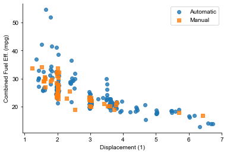

```python
ttype_markers = [('Automatic','o'),
                 ('Manual','s')]

for ttype,marker in ttype_markers:
    plot_data = fuel_econ_subset[fuel_econ_subset['trans_type']== ttype]
    sns.regplot(data = plot_data, x='displ',y='comb',
                x_jitter=0.04, fit_reg=False, marker = marker)
plt.xlabel('Displacement (1)')
plt.ylabel('Combined Fuel Eff. (mpg)')
plt.legend(['Automatic','Manual'])
sns.set_theme(style='ticks')
sns.despine()
plt.grid(False)
```

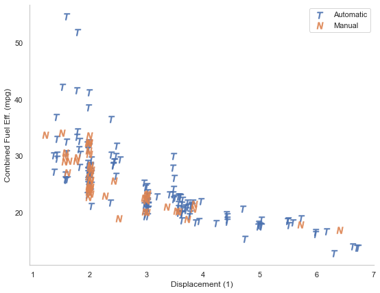

```python
ttype_markers = [('Automatic','$T$'),
                 ('Manual','$N$')]
plt.figure(figsize=(9,7))
for ttype,marker in ttype_markers:
    plot_data = fuel_econ_subset[fuel_econ_subset['trans_type']== ttype]
    sns.regplot(data = plot_data, x='displ',y='comb',
                x_jitter=0.04, fit_reg=False, marker = marker,scatter_kws={'s':90}) #,'sizes':(90,90)})
plt.xlabel('Displacement (1)')
plt.ylabel('Combined Fuel Eff. (mpg)')
plt.legend(['Automatic','Manual'])
sns.set_theme(style='ticks')
sns.despine()
plt.grid(False)
```

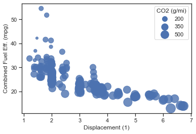

```python
sns.regplot(data = fuel_econ_subset, x='displ',y='comb',
                x_jitter=0.04, fit_reg=False, scatter_kws={'s':fuel_econ_subset['co2']/2})
plt.xlabel('Displacement (1)')
plt.ylabel('Combined Fuel Eff. (mpg)')

# dummy series for adding legend
sizes = [200, 350, 500]
base_color = sns.color_palette()[0]
legend_obj = []
for s in sizes:
    legend_obj.append(plt.scatter([], [], s = s/2, color = base_color))
plt.legend(legend_obj, sizes, title='CO2 (g/mi)')
```

```
([], [])
```

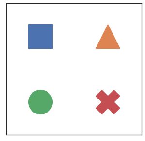

```python
plt.figure(figsize = [5,5])

common_size = 2500
plt.scatter([0],[1], marker = 's', s = common_size)
plt.scatter([1],[1], marker = '^', s = common_size)
plt.scatter([0],[0], marker = 'o', s = common_size)
plt.scatter([1],[0], marker = 'X', s = common_size)

# a little bit of aesthetic cleaning
plt.xlim(-0.5,1.5)
plt.xticks([])
plt.ylim(-0.5,1.5)
plt.yticks([])
```

```
([], [])
```

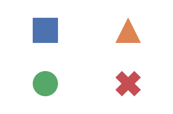

```python
plt.scatter([0],[1], marker = 's', s = common_size)
plt.scatter([1],[1], marker = '^', s = common_size)
plt.scatter([0],[0], marker = 'o', s = common_size)
plt.scatter([1],[0], marker = 'X', s = common_size)

plt.xlim(-0.5,1.5)
plt.ylim(-0.5,1.5)
sns.despine(bottom=True,left=True)
plt.xticks([])
plt.yticks([])
```

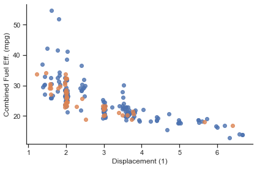

```python
g = sns.FacetGrid(data = fuel_econ_subset, hue = 'trans_type',
                 hue_order = ['Automatic','Manual'],size = 4, aspect = 1.5)
g.map(sns.regplot, 'displ', 'comb', x_jitter=0.04,fit_reg=False)
plt.xlabel('Displacement (1)')
plt.ylabel('Combined Fuel Eff. (mpg)');
```

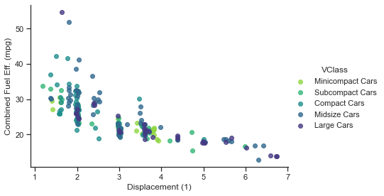

```python
g = sns.FacetGrid(data = fuel_econ_subset, hue = 'VClass', palette ='viridis_r',
                 size = 4, aspect = 1.5)
g.map(sns.regplot, 'displ', 'comb', x_jitter=0.04,fit_reg=False)
g.add_legend()
plt.xlabel('Displacement (1)')
plt.ylabel('Combined Fuel Eff. (mpg)');
```

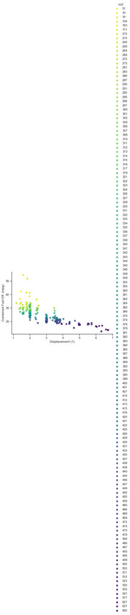

```python
g = sns.FacetGrid(data = fuel_econ_subset, hue = 'co2', palette ='viridis_r',
                 size = 4, aspect = 1.5)
g.map(sns.regplot, 'displ', 'comb', x_jitter=0.04,fit_reg=False)
g.add_legend()
plt.xlabel('Displacement (1)')
plt.ylabel('Combined Fuel Eff. (mpg)');
```

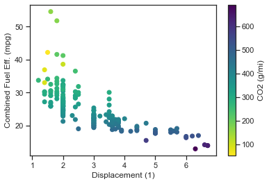

```python
plt.scatter(data = fuel_econ_subset,x='displ', y='comb', c = 'co2', cmap ='viridis_r')

plt.xlabel('Displacement (1)')
plt.ylabel('Combined Fuel Eff. (mpg)')
plt.colorbar(label='CO2 (g/mi)');
```

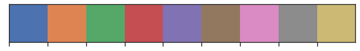

```python
sns.palplot(sns.color_palette(n_colors=9))   # qualitative palette
```

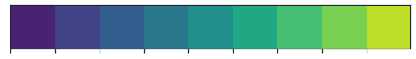

```python
sns.palplot(sns.color_palette('viridis', 9))   # sequential palette
```

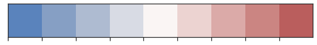

```python
sns.palplot(sns.color_palette('vlag', 9))  # diverging palette
```

[output not shown]

```
([], [])
```

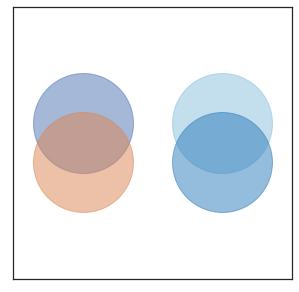

```python
plt.figure(figsize = [5,5])

# left: qualitative points
plt.scatter(0,0.5,s = 1e4, c = sns.color_palette()[0], alpha = 0.5)
plt.scatter(0,-0.5,s = 1e4, c = sns.color_palette()[1], alpha = 0.5)

# right: quantitative points
plt.scatter(1,0.5,s = 1e4, c = sns.color_palette('Blues')[2], alpha = 0.5)
plt.scatter(1,-0.5,s = 1e4, c = sns.color_palette('Blues')[4], alpha = 0.5)

# set axes for point overlap
plt.xlim(-0.5,1.5)
plt.ylim(-3.5,3.5)
plt.xticks([])
plt.yticks([])
```

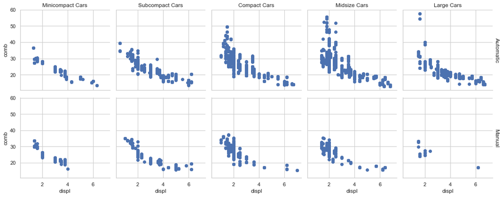

```python
g = sns.FacetGrid(data = fuel_econ, col = 'VClass',row = 'trans_type',
                 margin_titles = True)
sns.set_theme(style='whitegrid')
g.map(plt.scatter, 'displ' , 'comb')
g.set_titles(row_template='{row_name}', col_template='{col_name}')
```

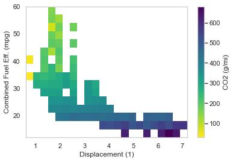

```python
# Specify bin edges
bins_x = np.arange(0.6, 7+0.3, 0.3)
bins_y = np.arange(12, 58+3, 3)

displ_bins = pd.cut(fuel_econ['displ'], bins_x, include_lowest = False,right=False,
                      labels=False).astype(int)#.to_frame('displ').groupby('displ').size()
comb_bins = pd.cut(fuel_econ['comb'], bins_y, include_lowest = False,right=False,
                      labels=False).astype(int)

n_points = fuel_econ.groupby([displ_bins,comb_bins]).size()
n_points = n_points.reset_index().pivot(index='displ',columns='comb').values

co2weights = fuel_econ['co2'] / n_points[displ_bins,comb_bins]
# Use cmin to set a minimum bound of counts
# Use cmap to reverse the color map.
h2d = plt.hist2d(data = fuel_econ, x = 'displ', y = 'comb', cmin=0.5, cmap='viridis_r', bins = [bins_x, bins_y],
                 weights=co2weights)

plt.xlabel('Displacement (1)')
plt.ylabel('Combined Fuel Eff. (mpg)')
plt.colorbar(label='CO2 (g/mi)');
```

```python
displ_binned = pd.cut(fuel_econ['displ'], bins_x, include_lowest = False,right=False,
                      labels=False).astype(int)#.to_frame('displ').groupby('displ').size()
comb_bins = pd.cut(fuel_econ['comb'], bins_y, include_lowest = False,right=False,
                   labels=False).astype(int)
displ_bins
```

```
0       10
1        4
2       10
3       10
4        6
        ..
3924     4
3925     4
3926     4
3927     9
3928     9
Name: displ, Length: 3929, dtype: int32
```

```python
displ_bins
comb_bins[5:15]
```

```
5     3
6     3
7     2
8     3
9     2
10    3
11    4
12    2
13    2
14    3
Name: comb, dtype: int32
```

```python
fuel_econ[5:15]['comb']
```

```
5     22.6002
6     21.4213
7     20.6507
8     23.8235
9     19.3344
10    21.2581
11    24.6323
12    20.9244
13    20.0543
14    21.0415
Name: comb, dtype: float64
```

```python
fuel_econ.groupby([displ_bins,comb_bins]).size().reset_index().pivot(index='displ',columns='comb')#.values
```

| comb displ | 0 | 0 1 | 0 2 | 0 3 | 0 4 | 0 5 | 0 6 | 0 7 | 0 8 | 0 9 | 0 10 | 0 11 | 0 12 | 0 13 | 0 14 | 0 15 |
| --- | --- | --- | --- | --- | --- | --- | --- | --- | --- | --- | --- | --- | --- | --- | --- | --- |
| 0 | NaN | NaN | NaN | NaN | NaN | NaN | NaN | 3.0 | NaN | 3.0 | NaN | NaN | NaN | NaN | NaN | NaN |
| 1 | NaN | NaN | NaN | NaN | NaN | NaN | 4.0 | 8.0 | NaN | NaN | NaN | NaN | NaN | NaN | NaN | NaN |
| 2 | NaN | NaN | NaN | NaN | NaN | 42.0 | 62.0 | 31.0 | 15.0 | 7.0 | 4.0 | NaN | NaN | NaN | NaN | NaN |
| 3 | NaN | NaN | NaN | 6.0 | 55.0 | 130.0 | 119.0 | 34.0 | 7.0 | NaN | 7.0 | 2.0 | 4.0 | 1.0 | 2.0 | 2.0 |
| 4 | NaN | NaN | 15.0 | 98.0 | 405.0 | 311.0 | 145.0 | 55.0 | 14.0 | 26.0 | 6.0 | 10.0 | 3.0 | 3.0 | 5.0 | NaN |
| 5 | NaN | NaN | 1.0 | 12.0 | 9.0 | NaN | 5.0 | 1.0 | NaN | NaN | NaN | NaN | NaN | NaN | NaN | NaN |
| 6 | NaN | NaN | 11.0 | 37.0 | 105.0 | 82.0 | 37.0 | 5.0 | 15.0 | 17.0 | NaN | 1.0 | NaN | 1.0 | NaN | NaN |
| 7 | NaN | NaN | 7.0 | 6.0 | NaN | NaN | NaN | NaN | NaN | NaN | NaN | NaN | NaN | NaN | NaN | NaN |
| 8 | NaN | NaN | 123.0 | 311.0 | 64.0 | 17.0 | 2.0 | NaN | NaN | NaN | NaN | NaN | NaN | NaN | NaN | NaN |
| 9 | NaN | NaN | 32.0 | 190.0 | 52.0 | 14.0 | 18.0 | NaN | NaN | NaN | NaN | NaN | NaN | NaN | NaN | NaN |
| 10 | NaN | 5.0 | 173.0 | 219.0 | 2.0 | NaN | NaN | NaN | NaN | NaN | NaN | NaN | NaN | NaN | NaN | NaN |
| 11 | NaN | 22.0 | 58.0 | 4.0 | NaN | NaN | NaN | NaN | NaN | NaN | NaN | NaN | NaN | NaN | NaN | NaN |
| 12 | NaN | 48.0 | 92.0 | NaN | NaN | NaN | NaN | NaN | NaN | NaN | NaN | NaN | NaN | NaN | NaN | NaN |
| 13 | 1.0 | 15.0 | 59.0 | NaN | NaN | NaN | NaN | NaN | NaN | NaN | NaN | NaN | NaN | NaN | NaN | NaN |
| 14 | NaN | 55.0 | 64.0 | NaN | NaN | NaN | NaN | NaN | NaN | NaN | NaN | NaN | NaN | NaN | NaN | NaN |
| 15 | NaN | 4.0 | NaN | NaN | NaN | NaN | NaN | NaN | NaN | NaN | NaN | NaN | NaN | NaN | NaN | NaN |
| 16 | 3.0 | 17.0 | 24.0 | NaN | NaN | NaN | NaN | NaN | NaN | NaN | NaN | NaN | NaN | NaN | NaN | NaN |
| 17 | NaN | 16.0 | 20.0 | NaN | NaN | NaN | NaN | NaN | NaN | NaN | NaN | NaN | NaN | NaN | NaN | NaN |
| 18 | 29.0 | 70.0 | 12.0 | NaN | NaN | NaN | NaN | NaN | NaN | NaN | NaN | NaN | NaN | NaN | NaN | NaN |
| 19 | 10.0 | 20.0 | 15.0 | NaN | NaN | NaN | NaN | NaN | NaN | NaN | NaN | NaN | NaN | NaN | NaN | NaN |
| 20 | 38.0 | 13.0 | NaN | NaN | NaN | NaN | NaN | NaN | NaN | NaN | NaN | NaN | NaN | NaN | NaN | NaN |
| 21 | NaN | 2.0 | NaN | NaN | NaN | NaN | NaN | NaN | NaN | NaN | NaN | NaN | NaN | NaN | NaN | NaN |

```python
n_points
```

```
array([[ nan,  nan,  nan,  nan,  nan,  nan,  nan,   3.,  nan,   3.,  nan,
         nan,  nan,  nan,  nan,  nan],
       [ nan,  nan,  nan,  nan,  nan,  nan,   4.,   8.,  nan,  nan,  nan,
         nan,  nan,  nan,  nan,  nan],
       [ nan,  nan,  nan,  nan,  nan,  42.,  62.,  31.,  15.,   7.,   4.,
         nan,  nan,  nan,  nan,  nan],
       [ nan,  nan,  nan,   6.,  55., 130., 119.,  34.,   7.,  nan,   7.,
          2.,   4.,   1.,   2.,   2.],
       [ nan,  nan,  15.,  98., 405., 311., 145.,  55.,  14.,  26.,   6.,
         10.,   3.,   3.,   5.,  nan],
       [ nan,  nan,   1.,  12.,   9.,  nan,   5.,   1.,  nan,  nan,  nan,
         nan,  nan,  nan,  nan,  nan],
       [ nan,  nan,  11.,  37., 105.,  82.,  37.,   5.,  15.,  17.,  nan,
          1.,  nan,   1.,  nan,  nan],
       [ nan,  nan,   7.,   6.,  nan,  nan,  nan,  nan,  nan,  nan,  nan,
         nan,  nan,  nan,  nan,  nan],
       [ nan,  nan, 123., 311.,  64.,  17.,   2.,  nan,  nan,  nan,  nan,
         nan,  nan,  nan,  nan,  nan],
       [ nan,  nan,  32., 190.,  52.,  14.,  18.,  nan,  nan,  nan,  nan,
         nan,  nan,  nan,  nan,  nan],
       [ nan,   5., 173., 219.,   2.,  nan,  nan,  nan,  nan,  nan,  nan,
         nan,  nan,  nan,  nan,  nan],
       [ nan,  22.,  58.,   4.,  nan,  nan,  nan,  nan,  nan,  nan,  nan,
         nan,  nan,  nan,  nan,  nan],
       [ nan,  48.,  92.,  nan,  nan,  nan,  nan,  nan,  nan,  nan,  nan,
         nan,  nan,  nan,  nan,  nan],
       [  1.,  15.,  59.,  nan,  nan,  nan,  nan,  nan,  nan,  nan,  nan,
         nan,  nan,  nan,  nan,  nan],
       [ nan,  55.,  64.,  nan,  nan,  nan,  nan,  nan,  nan,  nan,  nan,
         nan,  nan,  nan,  nan,  nan],
       [ nan,   4.,  nan,  nan,  nan,  nan,  nan,  nan,  nan,  nan,  nan,
         nan,  nan,  nan,  nan,  nan],
       [  3.,  17.,  24.,  nan,  nan,  nan,  nan,  nan,  nan,  nan,  nan,
         nan,  nan,  nan,  nan,  nan],
       [ nan,  16.,  20.,  nan,  nan,  nan,  nan,  nan,  nan,  nan,  nan,
         nan,  nan,  nan,  nan,  nan],
       [ 29.,  70.,  12.,  nan,  nan,  nan,  nan,  nan,  nan,  nan,  nan,
         nan,  nan,  nan,  nan,  nan],
       [ 10.,  20.,  15.,  nan,  nan,  nan,  nan,  nan,  nan,  nan,  nan,
         nan,  nan,  nan,  nan,  nan],
       [ 38.,  13.,  nan,  nan,  nan,  nan,  nan,  nan,  nan,  nan,  nan,
         nan,  nan,  nan,  nan,  nan],
       [ nan,   2.,  nan,  nan,  nan,  nan,  nan,  nan,  nan,  nan,  nan,
         nan,  nan,  nan,  nan,  nan]])
```

```python
#fuel_econ['co2'] /
n_points[displ_bins,comb_bins].shape
```

```
(3929,)
```

```python
#fuel_econ['co2'] /
# pd.DataFrame(n_points[displ_bins] == n_points[comb_bins]).head(50)
n_points[displ_bins].shape
```

```
(3929, 16)
```

```python
#fuel_econ['co2'] /
pd.DataFrame(n_points[displ_bins])
```

|  | 0 | 1 | 2 | 3 | 4 | 5 | 6 | 7 | 8 | 9 | 10 | 11 | 12 | 13 | 14 | 15 |
| --- | --- | --- | --- | --- | --- | --- | --- | --- | --- | --- | --- | --- | --- | --- | --- | --- |
| 0 | NaN | 5.0 | 173.0 | 219.0 | 2.0 | NaN | NaN | NaN | NaN | NaN | NaN | NaN | NaN | NaN | NaN | NaN |
| 1 | NaN | NaN | 15.0 | 98.0 | 405.0 | 311.0 | 145.0 | 55.0 | 14.0 | 26.0 | 6.0 | 10.0 | 3.0 | 3.0 | 5.0 | NaN |
| 2 | NaN | 5.0 | 173.0 | 219.0 | 2.0 | NaN | NaN | NaN | NaN | NaN | NaN | NaN | NaN | NaN | NaN | NaN |
| 3 | NaN | 5.0 | 173.0 | 219.0 | 2.0 | NaN | NaN | NaN | NaN | NaN | NaN | NaN | NaN | NaN | NaN | NaN |
| 4 | NaN | NaN | 11.0 | 37.0 | 105.0 | 82.0 | 37.0 | 5.0 | 15.0 | 17.0 | NaN | 1.0 | NaN | 1.0 | NaN | NaN |
| ... | ... | ... | ... | ... | ... | ... | ... | ... | ... | ... | ... | ... | ... | ... | ... | ... |
| 3924 | NaN | NaN | 15.0 | 98.0 | 405.0 | 311.0 | 145.0 | 55.0 | 14.0 | 26.0 | 6.0 | 10.0 | 3.0 | 3.0 | 5.0 | NaN |
| 3925 | NaN | NaN | 15.0 | 98.0 | 405.0 | 311.0 | 145.0 | 55.0 | 14.0 | 26.0 | 6.0 | 10.0 | 3.0 | 3.0 | 5.0 | NaN |
| 3926 | NaN | NaN | 15.0 | 98.0 | 405.0 | 311.0 | 145.0 | 55.0 | 14.0 | 26.0 | 6.0 | 10.0 | 3.0 | 3.0 | 5.0 | NaN |
| 3927 | NaN | NaN | 32.0 | 190.0 | 52.0 | 14.0 | 18.0 | NaN | NaN | NaN | NaN | NaN | NaN | NaN | NaN | NaN |
| 3928 | NaN | NaN | 32.0 | 190.0 | 52.0 | 14.0 | 18.0 | NaN | NaN | NaN | NaN | NaN | NaN | NaN | NaN | NaN |

3929 rows × 16 columns

```python
#fuel_econ['co2'] /
pd.DataFrame(n_points[displ_bins,comb_bins])
```

|  | 0 |
| --- | --- |
| 0 | 173.0 |
| 1 | 405.0 |
| 2 | 173.0 |
| 3 | 173.0 |
| 4 | 82.0 |
| ... | ... |
| 3924 | 5.0 |
| 3925 | 26.0 |
| 3926 | 6.0 |
| 3927 | 190.0 |
| 3928 | 190.0 |

3929 rows × 1 columns

```python
displ_bins#.value_counts()
```

```
0       10
1        4
2       10
3       10
4        6
        ..
3924     4
3925     4
3926     4
3927     9
3928     9
Name: displ, Length: 3929, dtype: int32
```

```python
x = np.array([[ 0,  1,  2],
              [ 3,  4,  5],
              [ 6,  7,  8],
              [ 9, 10, 11]])
rows = np.array([[0, 0,1,3],
                 [3, 3,2,1]], dtype=np.intp)
columns = np.array([[0, 2, 1, 2],
                    [0, 2, 1, 1]], dtype=np.intp)
x[rows, columns]
```

```
array([[ 0,  2,  4, 11],
       [ 9, 11,  7,  4]])
```

```python
x = np.array([[ 0,  1,  2],
              [ 3,  4,  5],
              [ 6,  7,  8],
              [ 9, 10, 11]])
rows = np.array([[0, 0],
                 [2, 1]], dtype=np.intp)
columns = np.array([[0, 2],
                    [1, 2]], dtype=np.intp)
x[rows, columns]
```

```
array([[0, 2],
       [7, 5]])
```

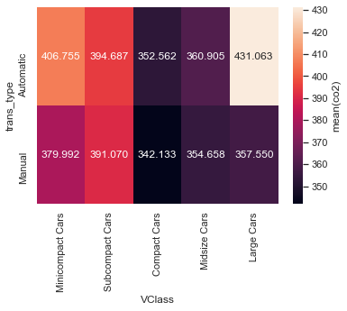

```python
cat_means = fuel_econ.groupby(['VClass', 'trans_type']).mean()['co2']
cat_means = cat_means.reset_index(name = 'co2_avg')
cat_means = cat_means.pivot(index = 'trans_type', columns = 'VClass',
                            values = 'co2_avg')
sns.heatmap(cat_means, annot = True, fmt = '.3f',
           cbar_kws = {'label' : 'mean(co2)'})#,cmap='viridis_r')
```

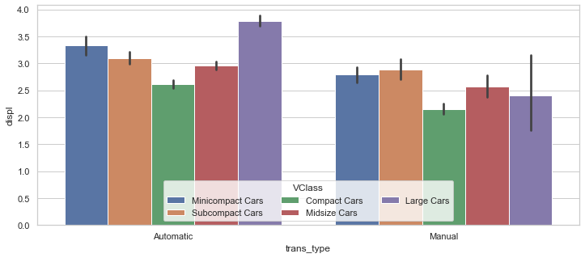

```python
plt.figure(figsize=(12,5))
ax = sns.barplot(data = fuel_econ, x = 'trans_type', y = 'displ', hue = 'VClass')
ax.legend(loc = 8, ncol = 3, framealpha = .8, title = 'VClass')
```

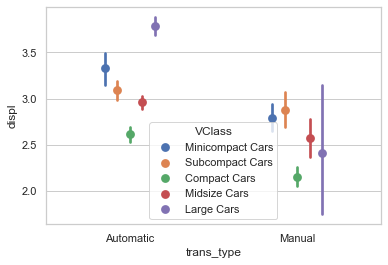

```python
ax = sns.pointplot(data = fuel_econ, x = 'trans_type', y = 'displ', hue = 'VClass',
                  dodge = 0.3, linestyles = "")
```

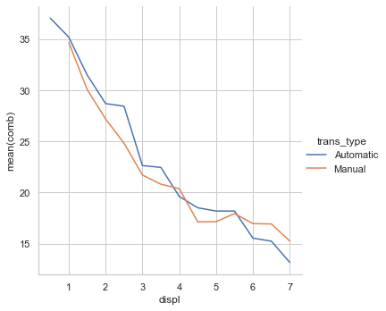

```python
def mean_poly(x, y, bins = 10, **kwargs):
    """ Custom adapted line plot code. """
    # set bin edges if none or int specified
    if type(bins) == int:
        bins = np.linspace(x.min(), x.max(), bins+1)
    bin_centers = (bin_edges[1:] + bin_edges[:-1]) / 2

    # compute counts
    data_bins = pd.cut(x, bins, right = False,
                       include_lowest = True)
    means = y.groupby(data_bins).mean()

    # create plot
    plt.errorbar(x = bin_centers, y = means, **kwargs)

bin_edges = np.arange(0.25, fuel_econ['displ'].max()+0.5, 0.5)
g = sns.FacetGrid(data = fuel_econ, hue = 'trans_type', size = 5)
g.map(mean_poly, "displ", "comb", bins = bin_edges)
g.set_ylabels('mean(comb)')
g.add_legend()
```

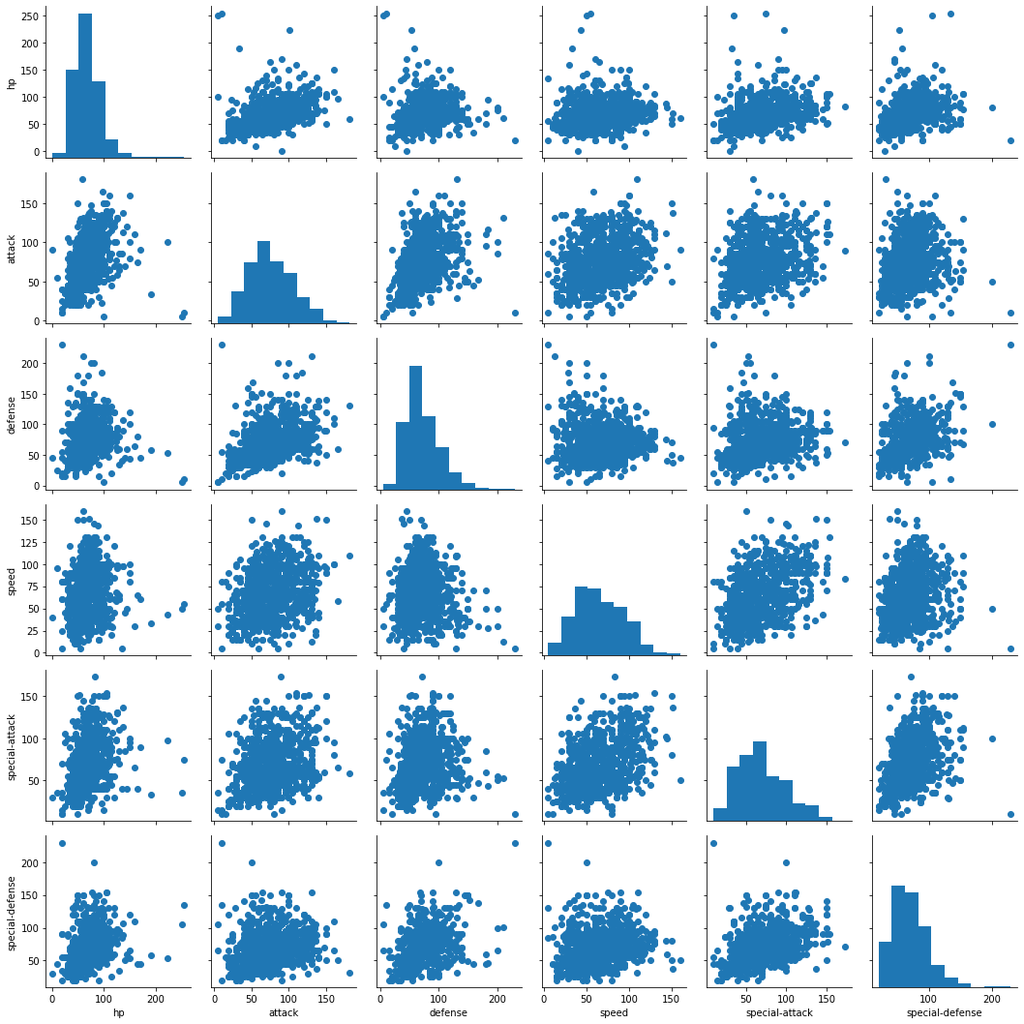

```python
pokemon_df = df.copy()

g = sns.PairGrid(data = pokemon_df, vars = ['hp','attack','defense','speed','special-attack','special-defense'])
g.map_diag(plt.hist)
g.map_offdiag(plt.scatter)
```

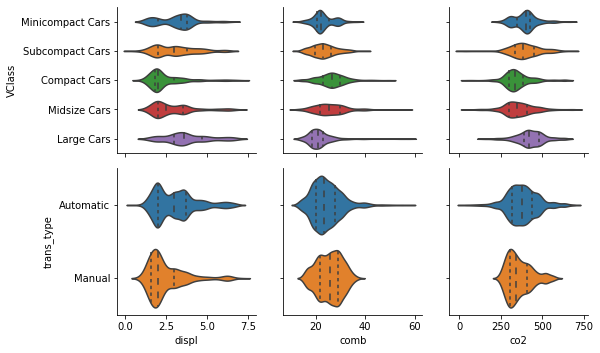

```python
# For other relationships, the flexibility of PairGrid shines.
# For example, if we want to look at the relationship between the numeric and categorical variables in the data,
# we need to set the different variable types on the rows and columns,
# then use an appropriate plot type for all matrix cells.

g = sns.PairGrid(data = fuel_econ, x_vars = ['displ','comb','co2'],
                y_vars = ['VClass','trans_type'])
g.map(sns.violinplot, inner = 'quartile')#,color=sns.color_palette()[0])
```

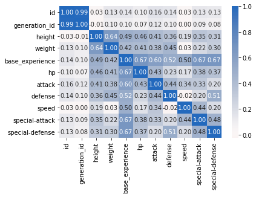

```python
sns.heatmap(pokemon_df.corr(), annot = True, fmt = '.2f', cmap = 'vlag_r', center = 0)
#pokemon_df.corr()
```

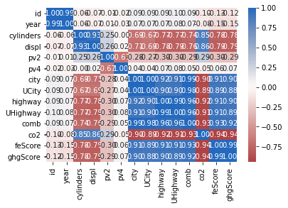

```python
sns.heatmap(fuel_econ.corr(), annot = True, fmt = '.2f', cmap = 'vlag_r', center = 0)
#fuel_econ.corr()
```

### Feature Engineering

```python
pokemon_df['atk_ratio'] = pokemon_df['attack'] / pokemon_df['special-attack']
pokemon_df['def_ratio'] = pokemon_df['defense'] / pokemon_df['special-defense']
```

```python
max(pokemon_df['atk_ratio'].value_counts().index)
```

```
8.0
```

```python
max(pokemon_df['def_ratio'].value_counts().index)
```

```
4.225806451612903
```

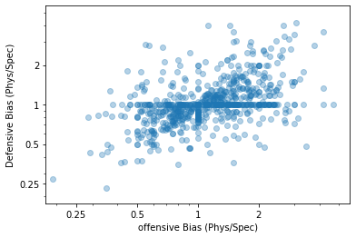

```python
plt.scatter(data = pokemon_df, x = 'atk_ratio', y = 'def_ratio', alpha = 1/3)
plt.xlabel('offensive Bias (Phys/Spec)')
plt.ylabel('Defensive Bias (Phys/Spec)')
plt.xscale('log')
plt.yscale('log')
tick_loc = [0.25, 0.5, 1, 2, 41]
plt.xticks(tick_loc, tick_loc)
plt.yticks(tick_loc, tick_loc)
plt.xlim(2 ** -2.5, 2 ** 2.5)
plt.ylim(2 ** -2.5, 2 ** 2.5);
```

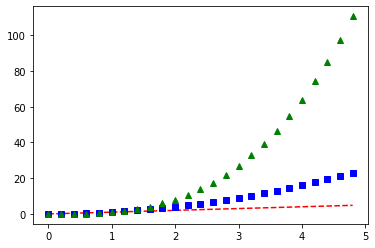

```python
# evenly sampled time at 200ms intervals
t = np.arange(0., 5., 0.2)

# red dashes, blue squares and green triangles
plt.plot(t, t, 'r--', t, t**2, 'bs', t, t**3, 'g^')
plt.show()
```

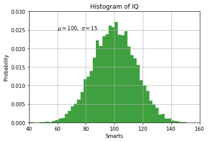

```python
mu, sigma = 100, 15
x = mu + sigma * np.random.randn(10000)

# the histogram of the data
n, bins, patches = plt.hist(x, 50, density=1, facecolor='g', alpha=0.75)


plt.xlabel('Smarts')
plt.ylabel('Probability')
plt.title('Histogram of IQ')
plt.text(60, .025, r'$\mu=100,\ \sigma=15$')
plt.axis([40, 160, 0, 0.03])
plt.grid(True)
plt.show()
```

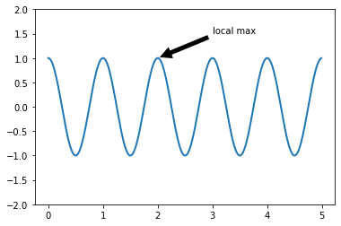

```python
ax = plt.subplot()

t = np.arange(0.0, 5.0, 0.01)
s = np.cos(2*np.pi*t)
line, = plt.plot(t, s, lw=2)

plt.annotate('local max', xy=(2, 1), xytext=(3, 1.5),
             arrowprops=dict(facecolor='black', shrink=0.05),
             )

plt.ylim(-2, 2)
plt.show()
```

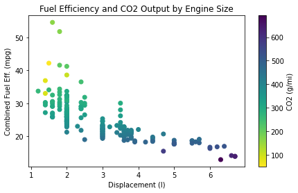

```python
# loading in the data, sampling to reduce points plotted
fuel_econ = pd.read_csv('fuel-econ.csv')

np.random.seed(2018)
sample = np.random.choice(fuel_econ.shape[0], 200, replace = False)
fuel_econ_subset = fuel_econ.loc[sample]

# plotting the data
plt.figure(figsize = [7,4])
plt.scatter(data = fuel_econ_subset, x = 'displ', y = 'comb', c = 'co2',
            cmap = 'viridis_r')
plt.title('Fuel Efficiency and CO2 Output by Engine Size')
plt.xlabel('Displacement (l)')
plt.ylabel('Combined Fuel Eff. (mpg)')
plt.colorbar(label = 'CO2 (g/mi)');
```